# Lab 9-13 bloque 1

```r
library(readxl)
icb = read_excel('info_clientes_banco.xlsx')
```

#### **Problema 9.** Obtenga un listado que contenga los saldos de cada una de las cuentas corrientes abiertas en el banco.

```r
lista_saldos_cc = icb[icb$Cuenta_corriente==1,]$Saldo_cuenta_corriente
```

Son demasiados para imprimirlos todos, así que imprimiremos sólo los primeros 30 para ver si los datos son correctos.

```r
print(lista_saldos_cc[0:30])
```

```
 [1] 1486285.66 1953145.96  914886.05  918757.17 1760718.43   89437.59
 [7] 1058108.12  820000.29 1441696.24  186530.84  800311.81 1483876.62
[13] 1250649.16 1211165.43  840511.88  618504.20 1717489.57  621590.09
[19]  421350.47  664142.02  473413.95  259074.00   80961.76 1787736.49
[25] 1631739.37  683931.58 1788166.32 1720663.25 1432635.66 1259449.64
```

#### **Problema 10.** ¿Cuál es el saldo total que tiene el banco en cuentas corrientes?

```r
saldo_cc = sum(lista_saldos_cc)
print('Total de saldo en cuentas corrientes:');saldo_cc
```

```
[1] "Total de saldo en cuentas corrientes:"
[1] 932768208
```

#### **Problema 11.** ¿El banco tiene más dinero en cuentas corrientes o de ahorros? ¿Cuál es la distribución porcentual de estas cantidades?

```r
lista_saldos_ca = icb[icb$Cuenta_ahorros==1,]$Saldo_cuenta_ahorros
saldo_ca = sum(lista_saldos_ca)

saldo_total = saldo_cc+saldo_ca
print('Saldo total:'); saldo_total
```

```
[1] "Saldo total:"
[1] 11380733098
```

```r
porcentaje_cc = (saldo_cc/saldo_total) * 100
porcentaje_ca = (saldo_ca/saldo_total) * 100

print('% de saldo CC:');porcentaje_cc
```

```
[1] "% de saldo CC:"
[1] 8.196029
```

```r
print('% de saldo CA:');porcentaje_ca
```

```
[1] "% de saldo CA:"
[1] 91.80397
```

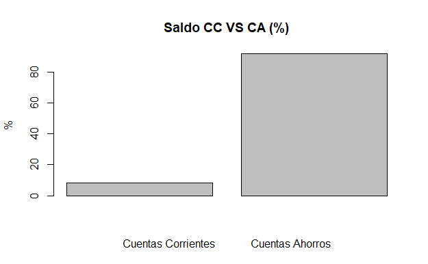

```r
barplot(c(porcentaje_cc,porcentaje_ca), main= 'Saldo CC VS CA (%)', xlab = 'Cuentas Corrientes             Cuentas Ahorros', ylab = '%' )
```

A la izquierda vemos el porcentaje de saldo que contienen las cuentas corrientes, es mucho menor que el que contienen las cuentas de ahorros.

#### **Problema 12.** Obtenga e interprete tablas de frecuencias absolutas y relativas para el segmento de clientes y tipos de clientes.

```r
print('Segmentos (Frecuencia absoluta):')
```

```
[1] "Segmentos (Frecuencia absoluta):"
```

```r
(tabla_segmentos_FA = table(icb$Segmento))
```

```
       ALTO   ALTO-PLUS      BASICO BASICO-PLUS       MEDIO  MEDIO-PLUS
        196         209         596         397         189         202
    PREMIUM
        209
```

Vemos que el mayor número de clientes tienen una cuenta básica, con 596 de ellos.

```r
print('Segmentos (Frecuencia relativa):')
```

```
[1] "Segmentos (Frecuencia relativa):"
```

```r
(tabla_segmentos_FR = (tabla_segmentos_FA/length(icb$Segmento)) * 100)
```

```
       ALTO   ALTO-PLUS      BASICO BASICO-PLUS       MEDIO  MEDIO-PLUS
   9.809810   10.460460   29.829830   19.869870    9.459459   10.110110
    PREMIUM
  10.460460
```

Su frecuencia relativa nos lo confirma. Con un porcentaje de 29%, es mucho mayor al de los demás segmentos o tipos de cuenta.

```r
print('Tipo de cliente (Frecuencia Absoluta):')
```

```
[1] "Tipo de cliente (Frecuencia Absoluta):"
```

```r
(tabla_tipo_FA = table(icb$Tipo_Cliente))
```

```
   APOSTOL   DECIDIDO   INDECISO NEGOCIADOR      REHEN
       209        214        607        196        772
```

Vemos que la mayoría de clientes son de tipo rehén, con 772 de ellos.

```r
print('Tipo de cliente (Frecuencia Relativa):')
```

```
[1] "Tipo de cliente (Frecuencia Relativa):"
```

```r
(tabla_tipo_FR = (tabla_tipo_FA/length(icb$Tipo_Cliente)) * 100)
```

```
   APOSTOL   DECIDIDO   INDECISO NEGOCIADOR      REHEN
  10.46046   10.71071   30.38038    9.80981   38.63864
```

La frecuencia relativa nos lo confirma, los clientes rehén tienen el mayor porcentaje entre los tipos de cliente.

#### **Problema 13.** Obtenga e interprete diagramas de barras para la información anterior.

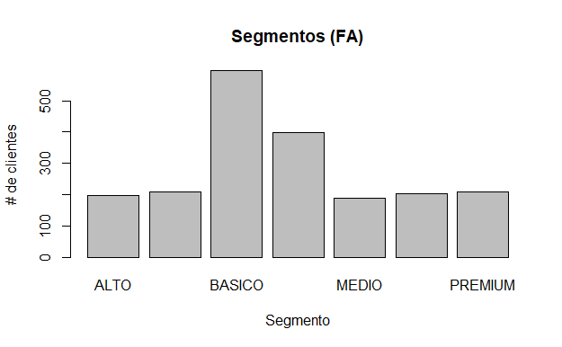

```r
barplot(tabla_segmentos_FA, main = 'Segmentos (FA)', xlab = 'Segmento', ylab = '# de clientes')
```

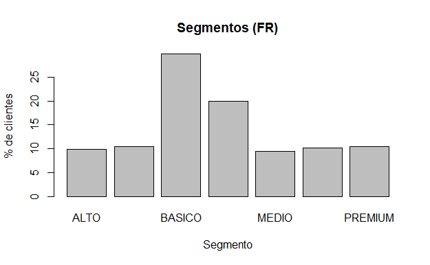

```r
barplot(tabla_segmentos_FR, main = 'Segmentos (FR)', xlab = 'Segmento', ylab = '% de clientes')
```

Los clientes con cuenta básica son los más comunes, teniendo la mayor frecuencia absoluta (y por lo tanto, relativa).

Los menos comunes son los de segmento alto y medio, ambos con apenas el 10% de los clientes.

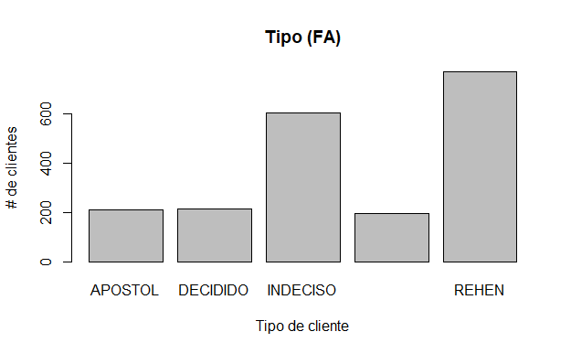

```r
barplot(tabla_tipo_FA, main = 'Tipo (FA)', xlab = 'Tipo de cliente', ylab = '# de clientes')
```

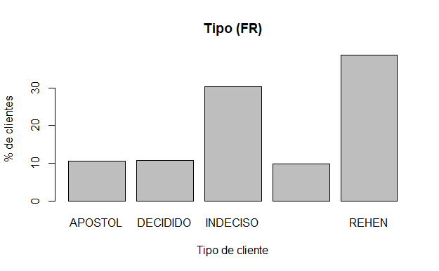

```r
barplot(tabla_tipo_FR, main = 'Tipo (FR)', xlab = 'Tipo de cliente', ylab = '% de clientes')
```

Los clientes de tipo rehén son los más abundantes, tienen una frecuencia absoluta (y también relativa) mucho mayor a la de los demás tipos, mientras que los apóstoles, decididos y negociadores tienen sólo un 10% cada uno.